# Modelling COVID-19 in South Africa at a Provincial Level

# 1 Introduction

This paper documents a model of the COVID-19 epidemic in South Africa. Mobility data is used to model the reproduction number of the COVID-19 epidemic over time using a Bayesian hierarchical model. Results are calibrated to reported deaths only. This is achieved by adapting the work in by Imperial College London researchers [1] for South Africa. Authors from Imperial College London have built similar models for Brazil [2] and the United States [3].

The model is based on data as compiled in [4]. The model uses mobility movement indexes by province produced by Google [5]. Furthermore the model includes a fixed effect for interventions introduced at the start of level 4 lockdown.

The model and report are automatically generated on a regular basis using R [6]. This version contains data available on 17 July 2020.

An online, regularly updated version of this report is [available here](https://lrossouw.github.io/covid-19/modelling_covid-19_in_south_africa_at_a_provincial_level.html).

# 2 Updates

As this paper is updated over time this section will summarise significant changes. The code producing this paper is tracked using git. The git commit hash for this project at the time of generating this paper was 9707b811da93281d2c01b2ae3afdf141bb39630c.

**2020-05-31**

- Document is made available online (pending review).

**2020-06-01**

- Added backtesting.

**2020-06-04**

- Incorporated feedback from reviewer 1.

**2020-06-08**

- Incorporated feedback from reviewer 2 and 3.
- Added a projection for South Africa (based on sum of the provinces).
- Created a CSV with the daily projections. See the projection section for details.
- Added an updates section to track changes to this model.

**2020-06-09**

- Incorporate feedback from reviewer 4.
- Remove the under review designation. As at this date the model has feedback from 4 reviewers and also comments from others. The author will continue to update this model and seek review as needed.
- Due to mobility increasing from Level 3 and additional projection scenarios has been introduced involving decreased mobility (back to level 4 levels).
- Numerous updates on plots including some residual plots.

**2020-06-10**

- Remove parks index from average mobility index in line with [7]. Will drop residential index soon too.

**2020-06-20**

- Update IFRs for HIV. Possibly need further increases based on research coming out in near future.
- Remove residential mobility, such that there is only one mobility parameter left.

**2020-06-22**

- Add parameter for fixed effects correlated with the start of level 4 lockdown aimed at capturing the effect of mask wearing and workplace screening.

**2020-07-04**

- Updated standard deviation of prior for $\beta$ to reflect [8]. This allows for a greater impact of mask wearing on $R_{t,m}$.
- $\beta_{m}^s$ prior updated to allow increases and decreases in effect of interventions implemented at start of level 4 lockdown.

**2020-07-07**

- Major changes to allow for excess deaths exceeding reported COVID-19 deaths.
- Expanded calibration graphs for more provinces.

**2020-07-16**

- Update excess reporting based on [9] data.
- Increase uncertainty around completeness of reporting factors.

# 3 Methodology

A detailed description of the methodology and assumptions is provided below below. The key features of the approach employed are summarised here:

- It uses a Bayesian Hierarchical Model to calibrate model parameters based on observed death data and prior assumptions.
- Changes in the reproductive number are linked to mobility data [5] as well as introduction of other non-pharmaceutical interventions (NPIs).
- The reproductive number over time is used to model the number of infections occurring over time.
- The model uses population weighted infection fatality ratio (IFRs) with some noise added as well as assumptions about the time it takes to die to model deaths from infections.
- There is a single combined model for all provinces. This model shares information between provinces, but province specific effects are also allowed.
- The model does not allow for most interventions that are not observable via mobility changes, for example this includes testing and contact tracing. The model includes the effect of the average level of these interventions. Social distancing, for example, may have reduced the reproduction number throughout the past period. However, the model will not take account to changes in these interventions. These interventions may also put a damper on increases in the reproductive number as mobility increases.
- The model is fitted such that it uses the prior assumptions about various parameters as well as the reported death data in such a way to provide an updated parameter distribution and outcome distribution that reflect both the prior assumptions as well as the reported death data.

# 4 Mobility

## 4.1 National Mobility Data

The national mobility data from [5] is plotted below. The model uses the indexes at a provincial level but here the national indexes are plotted for convenience. Clear trends are observable:

- Mobility generally reduces before the lockdown on 27 March.
- There is an increase in mobility in the days just before the lockdown. In particular the Grocery & Pharmacy and Retail indexes. Perhaps an indication of pre-lockdown “panic buying”?
- Mobility is relatively stable during level 5 lockdown at low levels.
- Mobility increases when level 4 starts.

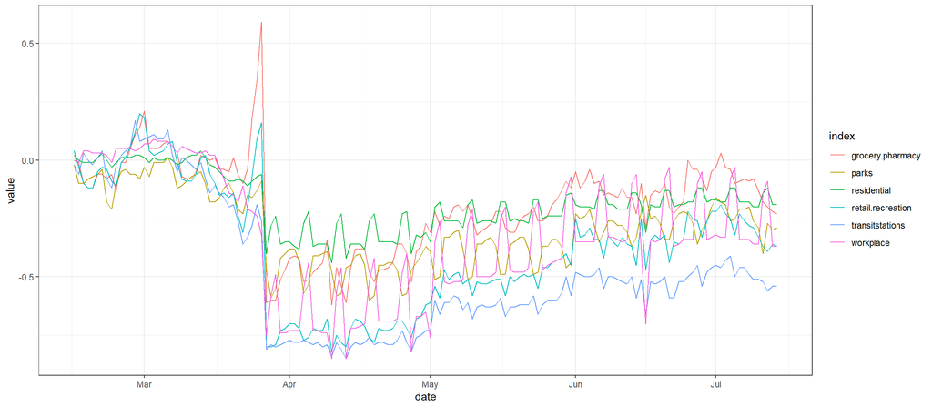

The chart below summarises the average mobility and residential indexes used in the model. This is the average of mobility indicators excluding parks and residential. This follows [7].

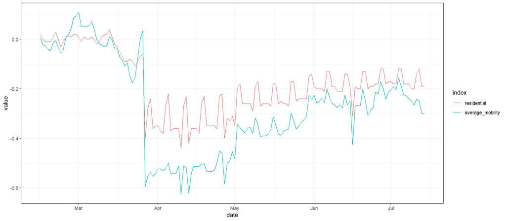

There are some risks of the mobility data above as it may be biased to the Android operating system, people with smartphones and people with enough data on their smartphone to share their location.

This bias does not really represent a problem though unless it changes over time because then the model would not be able to produce accurate projections. There is a risk that mobility changes disproportionally between users contributing data to these indexes and those not. It would not seem reasonable to expect a major change in the bias over time (unless the calculation is somehow compromised). Provincial biases may exist, but the model also allows the provinces to exhibit provincial specific mobility effects for both parameters.

## 4.2 Provincial Mobility Data

The average mobility (excluding residential & park indexes) is plotted below for the various provinces. From this plot it seems apparent that Western Cape mobility has reduced the most during lockdown and is, perhaps, increasing slower.

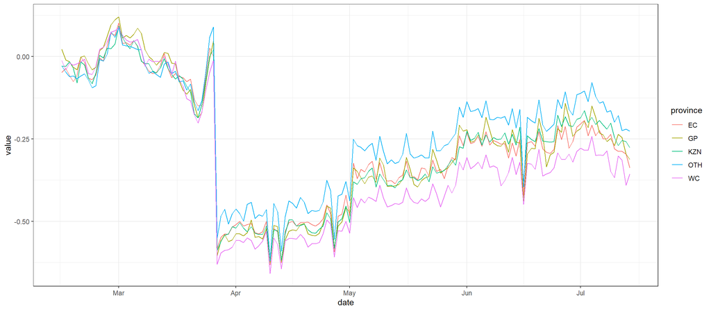

# 5 Calibration

The sections below show how well the model is reproducing past death data. As the model is fitted to past death data we would want to see how well it’s reproducing such data. Each section covers a province.

Three panels are plotted for each province:

1. The first panel shows the modelled daily number of infections (blue) compared to confirmed case counts (brown) as reported for the province. Note that this model does not calibrate to case data, but this data is shown for reference. We expect the model to produce infections exceeding confirmed cases as testing is likely only finding a fraction of the true infections. For example, New York City was estimated to have as many as 2.7m total infections as measured by antibody testing by April 2020 while only have 263 000 confirmed cases at that time [10].
2. The second shows the daily count of deaths reported in the province (brown) and the modelled deaths in blue. A good model would produce death forecasts such that the actual reported past deaths would appear in the confidence intervals of the prediction.
3. The third panel shows the estimates for reproductive number ($R_{t,m}$) over time ($t$) for each province ($m$). These values are generating the infections in the model which result in deaths. Note that due to the delay of deaths following infections the last week or two of $R_{t,m}$ values already present an extrapolation from the data. Deaths as a result of these recent infections have generally not occurred as yet.

In all the charts the darker shaded area represents a confidence interval of 50% and the lighter shaded area represents a confidence interval of 95%.

In general, it is noted:

- The model appears to provide a reasonable fit to daily number of deaths reported (where there is enough data).
- $R_{t,m}$ dropped significantly from the declaration of state of disaster, closure of schools and the implementation of lockdown.
- $R_{t,m}$ picked up in the days ahead of the start of Level 5 lockdown, presumably as people prepared for lockdown.
- $R_{t,m}$ dropped significantly during Level 5 lockdown. For most provinces it did not drop below 1. $R_{t,m}$ below 1 would indicate a epidemic where each infection is generating less than 1 further infection. This would be an epidemic that is slowing down and should $R_{t,m}$ be sustained below 1 such an epidemic would stop.
- $R_{t,m}$ is modelled to move higher after the start of Level 4 lockdown and further with the start of Level 3.

## 5.1 Western Cape

The Western Cape has the most reported deaths of all provinces and hence the most data to calibrate. The modelled infections are plotted below. It’s clear that modelled infections are far outpacing reported cases (brown).

Over the last 14 days it would appear that the Western Cape only tested 4.4% of all new infections. This figure seems quite low, but it seems that the growth in infection in the last number of weeks coincided with a large backlog of tests as well as a change in Western Cape testing policy. The Western Cape is limiting tests due to shortages to only higher risk groups [11].

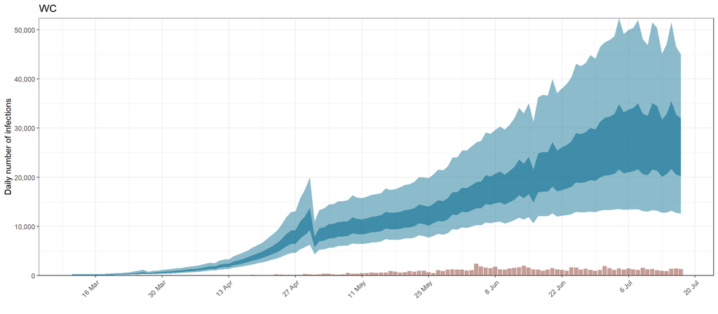

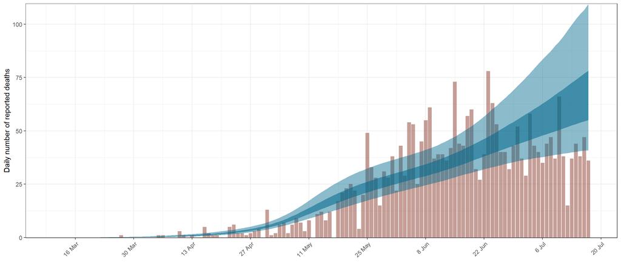

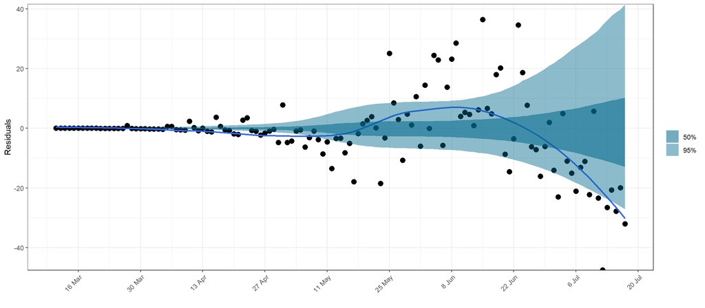

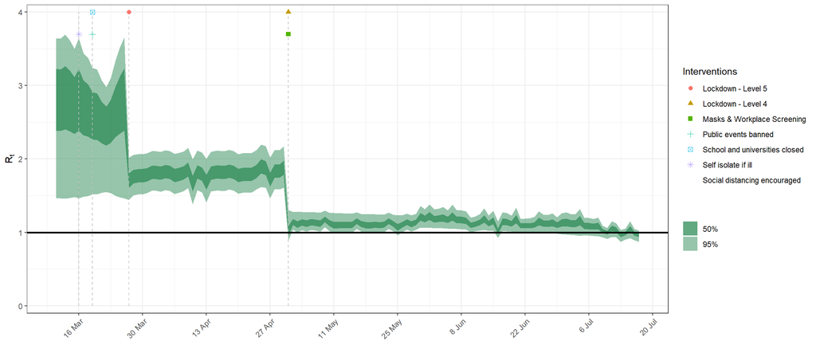

## 5.2 Eastern Cape

Below modelled infections are plotted compared to confirmed cases. Over the last 14 days it would appear that 4.1% of all new infections were tested.

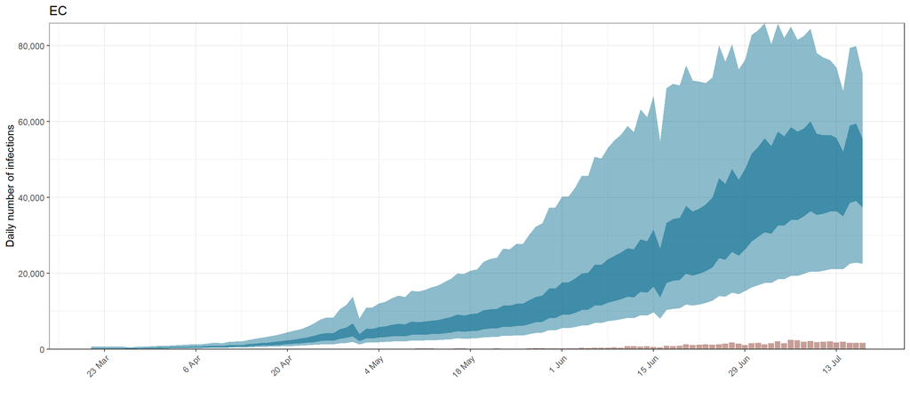

The reported deaths (in brown) and modelled reported deaths (in blue) are plotted below. Model for Eastern Cape also appears slightly on the high side but less so that the Western Cape.

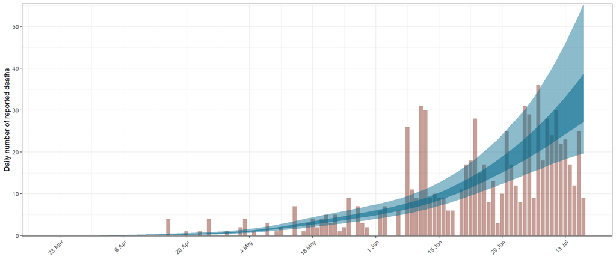

Below we plot the residuals by day.

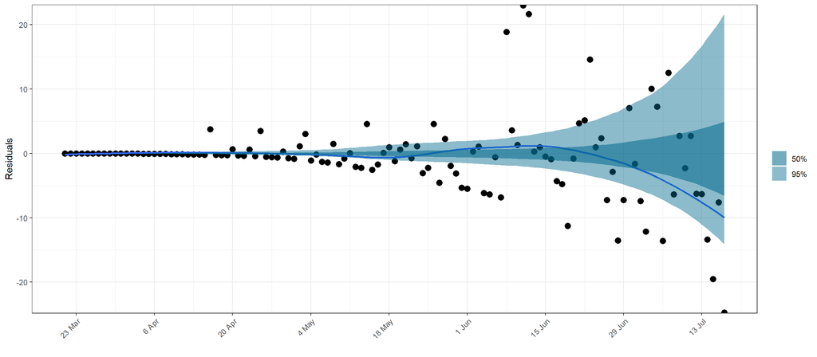

Below the $R_{t,m}$ is plotted:

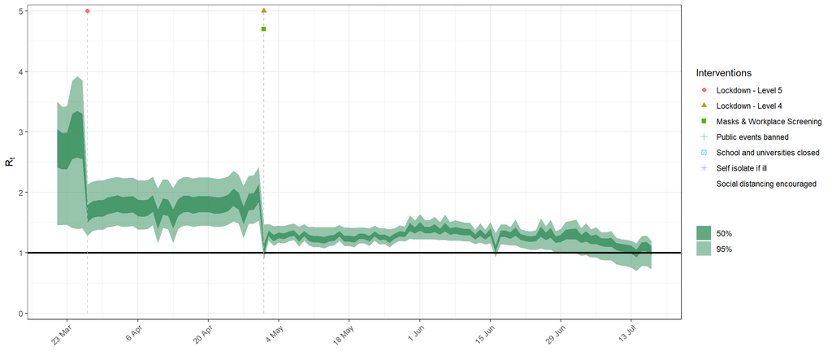

## 5.3 Gauteng

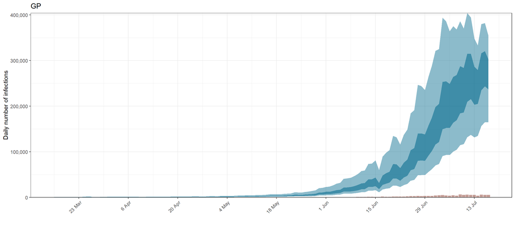

The reported deaths (in brown) and modelled reported deaths (in blue) are plotted below.

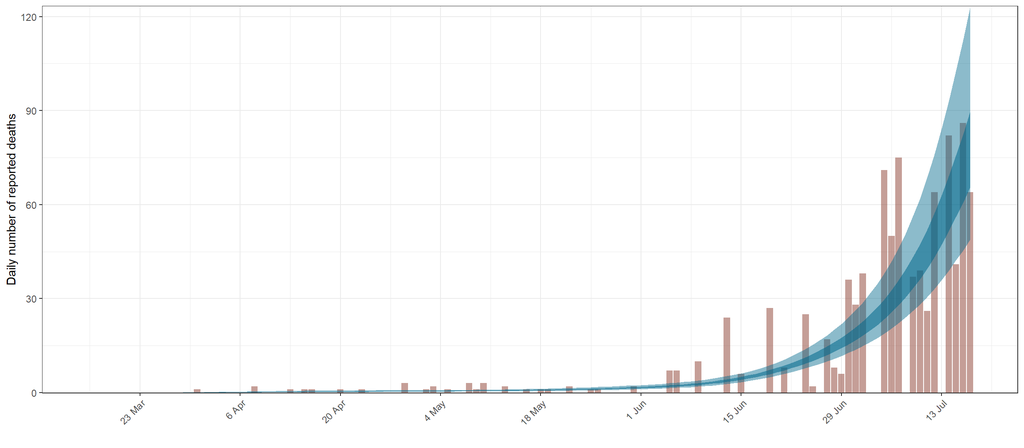

Below we plot the residuals by day.

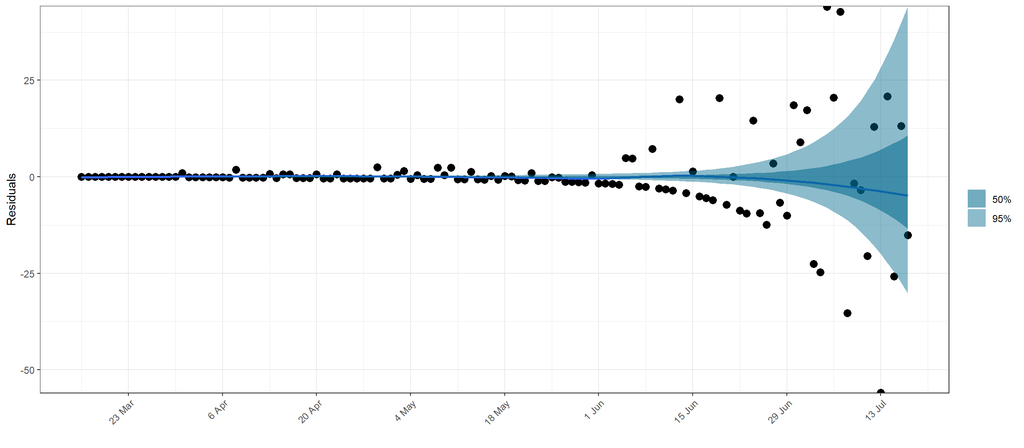

Below the $R_{t,m}$ is plotted:

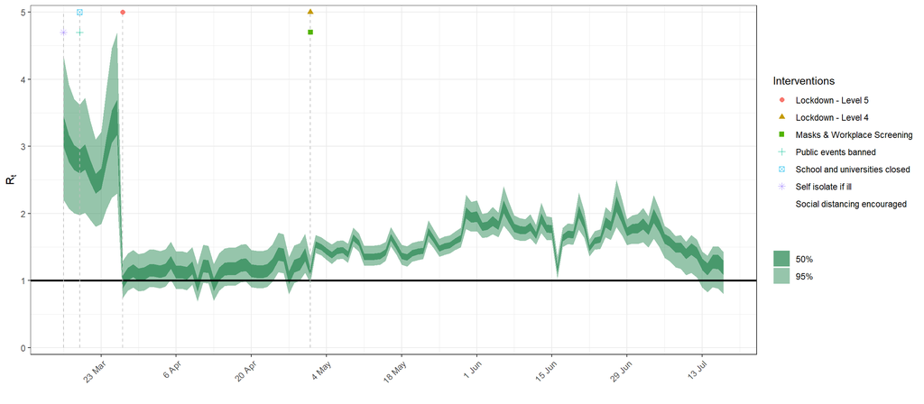

## 5.4 KwaZulu-Natal

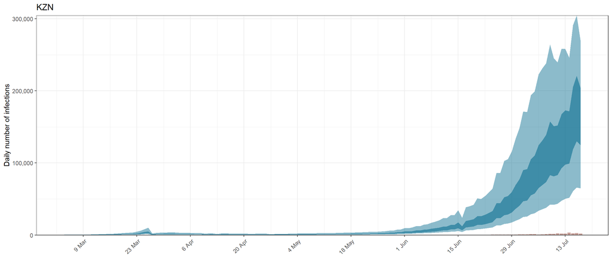

The reported deaths (in brown) and modelled reported deaths (in blue) are plotted below.

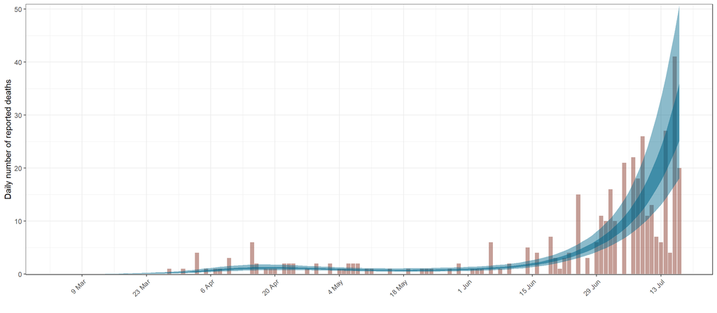

Below we plot the residuals by day.

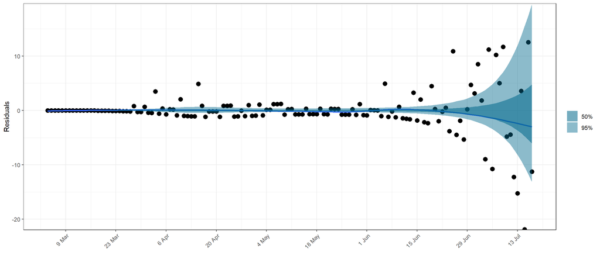

Below the $R_{t,m}$ is plotted:

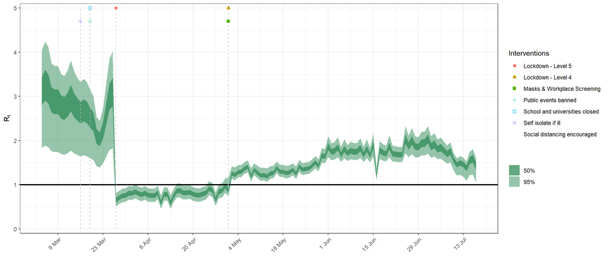

## 5.5 Other Provinces

The other provinces have limited data.

Over the last 14 days it would appear that 1.4% of all new infections were tested.

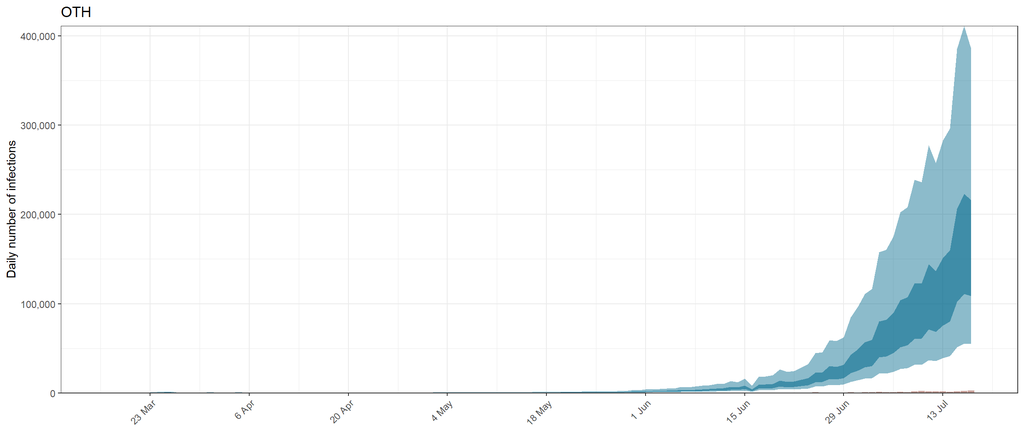

The reported deaths (in brown) and modelled reported deaths (in blue) are plotted below.

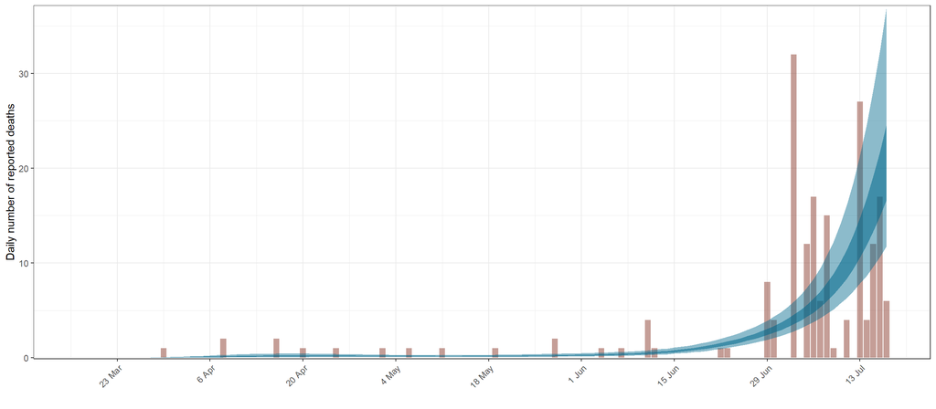

Below we plot the residuals by day.

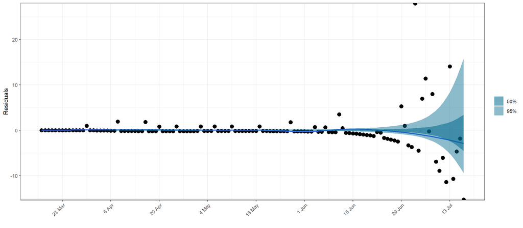

Below the $R_{t,m}$ is plotted:

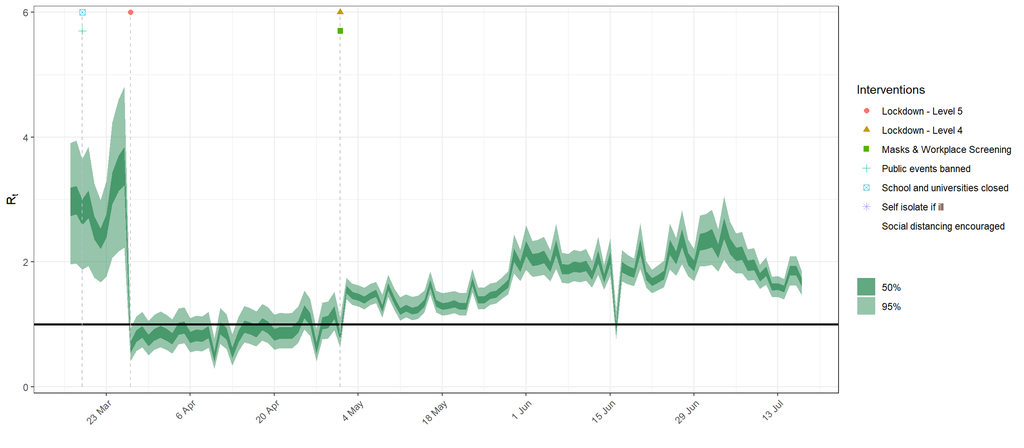

# 6 Parameter Estimates

To understand the net parameter estimates for $\alpha$ and $\alpha_{m}^s$ and their impact on $R_{t,m}$ we plot the percentage reduction in $R_{t,m}$ assuming the particular index is 1 (representing a 100% reduction in average mobility).

This is equivalent to plotting $1-2\cdot\phi^{-1}(-(\alpha+\alpha_{m}^s))$ for a particular province $m$. We also plot $1-2\cdot\phi^{-1}(-(\beta+\beta_{m}^s))$.

Confidence intervals are wide, though the average mobility index shows a big impact on $R_{t,m}$ (assuming 100% reduction in mobility). Interventions introduced with level 4 lockdown also seem to be reducing $R_{t,m}$ on average between 10% and 30%.

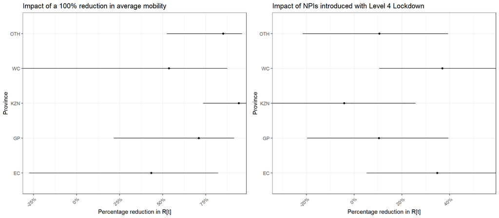

# 7 Reproduction Number Estimates

## 7.1 Initial Reproduction Number

Estimates for $R_{0,m}$ for each province are plotted below. It is clear that the posterior estimates for $R_{0,m}$ is not heavily influenced by the data. This is probably due to the relatively early lockdown implemented in South Africa. There were probably not enough deaths that resulted from infection prior to lockdown to develop an independent estimate for each province of $R_{0,m}$.

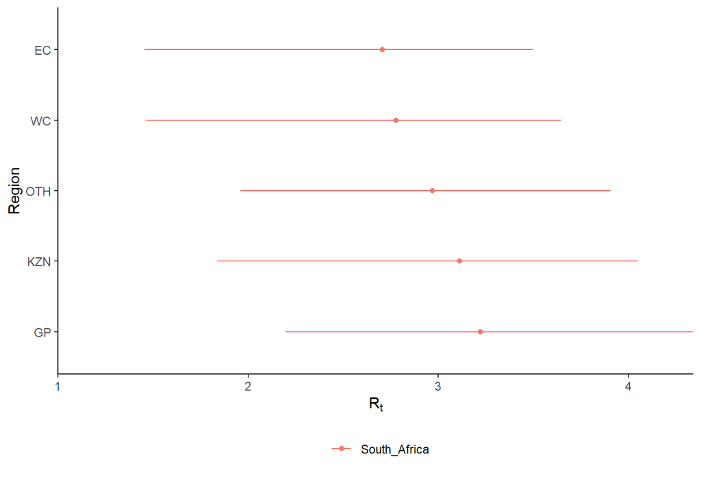

## 7.2 Current Reproduction Number as at 17 July 2020

The wide confidence intervals would indicate that we need to wait for the epidemic to further develop to include more data in our models. The confidence interval for Western Cape is narrowing already.

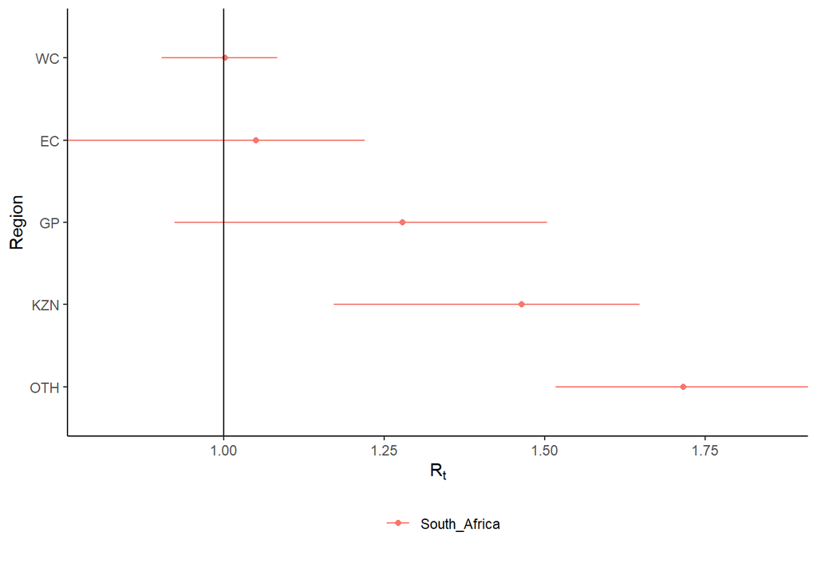

# 8 Attack Rate as at 17 July 2020

The estimated attack rate (with 95% confidence intervals) is tabulated below. This is the proportion of the population infected to date. This figure has to be estimated, because many that are infected experience no or mild symptoms, thus they may not seek medical advice and hence will never be tested.

The Western Cape figures may seem high but a recent presentation indicate positive rates from 20% to 40% during the final weeks of May 2020 depending on sub-district and whether it’s private or public health facilities doing the tests [12]. The public sector testing does seem closer to a 30% proportion positive at present from the graphs in that presentation. This information is not equivalent to an attack rate, but may be indicative of high numbers of infections being modelled here, especially those that have occurred relatively recently.

| Province | Attack Rate |
| --- | --- |
| EC | 27.85% [12.06%-54.68%] |
| GP | 35.66% [17.70%-59.56%] |
| KZN | 23.58% [8.97%-47.60%] |
| WC | 22.83% [14.12%-35.25%] |
| OTH | 10.71% [3.66%-24.64%] |
| South Africa | 22.99% [15.63%-32.43%] |

# 9 Projections

One of the reasons we build models is so that we can make sense of the future or indeed the past. We can project forward models to assess the impact of varying assumptions on future outcomes. This gives us a sense of how changes in actions may impact the future. I.e. it allows us to answer “what if” questions. Note however that in projecting the future we are extrapolating, and due care needs to be taken. There are numerous limitations to this model and these projections dicussed below but the author is also of the opinion that the projections add value in that they indicate a significant range across the scenarios projected and in such a manner inform discussion.

> All models are wrong but some are useful - George Box [13]

An incorrect model can be useful because it enables a better understanding of the model and the phenomena being modelled. This section should be used with caution because, as we show in calibration and backtesting, the model seems to be projecting higher deaths than observed for the Western Cape and Eastern Cape.

Note detailed projection output can be found here.

## 9.1 No change in Mobility

The first projections holds mobility constant at current levels which would be associated with level 3 of lockdown. Level 4 interventions are left intact.

The result of this scenario as at 31 December 2020 is tabulated below.

| Province | Attack Rate | Reported Deaths | Peak Daily Reported Deaths | Peak Reported Date | Deaths | Peak Daily Deaths | Peak Date |
| --- | --- | --- | --- | --- | --- | --- | --- |
| EC | 52.84% [40.09%-65.72%] | 4 044 [ 1 630- 7 770] | 50 | 2020-08-10 | 22 709 [ 16 180- 29 832] | 284 | 2020-08-06 |
| GP | 74.43% [67.11%-81.06%] | 10 682 [ 4 704-19 036] | 219 | 2020-08-11 | 50 244 [ 39 818- 61 415] | 1 033 | 2020-08-10 |
| KZN | 73.66% [64.49%-81.13%] | 7 607 [ 3 082-14 028] | 148 | 2020-08-19 | 39 431 [ 31 100- 48 127] | 768 | 2020-08-17 |
| WC | 40.29% [27.05%-52.95%] | 8 129 [ 5 255-11 613] | 79 | 2020-08-04 | 13 483 [ 8 948- 18 432] | 131 | 2020-08-03 |
| OTH | 75.86% [67.05%-83.37%] | 14 371 [ 5 523-27 248] | 292 | 2020-08-28 | 71 149 [ 55 642- 87 148] | 1 445 | 2020-08-27 |
| South Africa | 68.30% [63.88%-72.40%] | 44 832 [30 794-61 592] | 724 | 2020-08-20 | 197 017 [174 854-220 343] | 3 367 | 2020-08-19 |

## 9.2 Increase in mobility

This scenario assumes future mobility half-way between current mobility levels (associated with level 3 of lockdown) and normal levels. Level 4 interventions are left intact. The attack rate and deaths after increasing mobility are tabulated below (as at 31 December 2020).

| Province | Attack Rate | Reported Deaths | Peak Daily Reported Deaths | Peak Reported Date | Deaths | Peak Daily Deaths | Peak Date |
| --- | --- | --- | --- | --- | --- | --- | --- |
| EC | 61.40% [40.85%-73.70%] | 4 773 [ 1 696- 9 696] | 62 | 2020-08-21 | 26 411 [ 16 917- 34 527] | 330 | 2020-08-17 |
| GP | 84.77% [77.32%-90.07%] | 12 223 [ 5 125-22 062] | 277 | 2020-08-14 | 57 239 [ 45 280- 69 539] | 1 278 | 2020-08-13 |
| KZN | 86.35% [75.95%-91.71%] | 8 943 [ 3 512-16 600] | 213 | 2020-08-19 | 46 233 [ 36 638- 56 113] | 1 092 | 2020-08-18 |
| WC | 51.97% [27.11%-67.71%] | 10 538 [ 5 360-15 984] | 101 | 2020-08-26 | 17 432 [ 8 917- 24 706] | 167 | 2020-08-26 |
| OTH | 86.48% [78.25%-92.25%] | 16 407 [ 6 310-31 150] | 410 | 2020-08-25 | 81 120 [ 64 078- 98 460] | 2 017 | 2020-08-24 |
| South Africa | 79.13% [72.94%-83.13%] | 52 884 [36 069-73 374] | 1 019 | 2020-08-21 | 228 435 [201 778-255 494] | 4 675 | 2020-08-20 |

Based on the above an increase mobility could mean roughly 31 000 more deaths by the end of the year.

## 9.3 Decreased mobility

This scenario assumes future mobility at average levels seen during level 4 lockdown. This may occur either through actual reinstatement of level 4, or perhaps can be considered as a possibility if increased mobility does not result in as much increase in the reproductive number.

The attack rate and deaths after decreased mobility are tabulated below (as at 31 December 2020).

| Province | Attack Rate | Reported Deaths | Peak Daily Reported Deaths | Peak Reported Date | Deaths | Peak Daily Deaths | Peak Date |
| --- | --- | --- | --- | --- | --- | --- | --- |
| EC | 48.28% [34.90%-63.42%] | 3 643 [ 1 586- 6 777] | 48 | 2020-08-06 | 20 735 [ 14 312- 28 256] | 276 | 2020-08-03 |
| GP | 66.25% [56.54%-76.11%] | 9 429 [ 4 376-16 523] | 195 | 2020-08-08 | 44 700 [ 34 765- 55 534] | 938 | 2020-08-06 |
| KZN | 55.90% [42.90%-69.57%] | 5 677 [ 2 520-10 220] | 103 | 2020-08-12 | 29 893 [ 21 521- 39 063] | 562 | 2020-08-10 |
| WC | 35.88% [24.19%-48.44%] | 7 223 [ 4 867-10 248] | 77 | 2020-07-31 | 12 004 [ 8 108- 16 556] | 129 | 2020-07-31 |
| OTH | 56.53% [43.42%-68.94%] | 10 586 [ 4 274-19 905] | 163 | 2020-08-26 | 52 939 [ 37 778- 68 889] | 837 | 2020-08-24 |
| South Africa | 55.57% [49.49%-61.59%] | 36 558 [25 921-49 395] | 545 | 2020-08-12 | 160 270 [138 269-183 292] | 2 566 | 2020-08-11 |

Based on the above a decrease in mobility could mean roughly 37 000 fewer deaths by the end of the year.

## 9.4 Western Cape

Below we plot projections for the Western Cape.

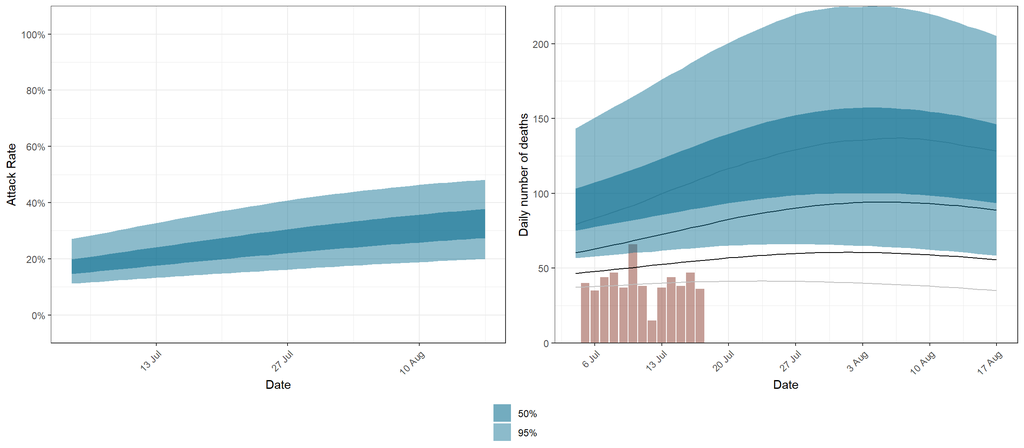

The attack rate and deaths over a longer period for both the constant mobility and increased mobility scenarios are plotted below:

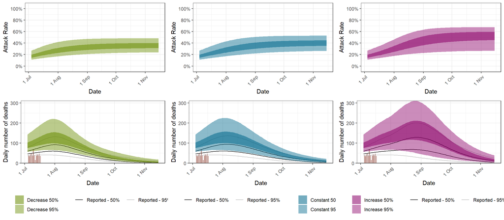

## 9.5 Eastern Cape

Below we plot the projections for Eastern Cape.

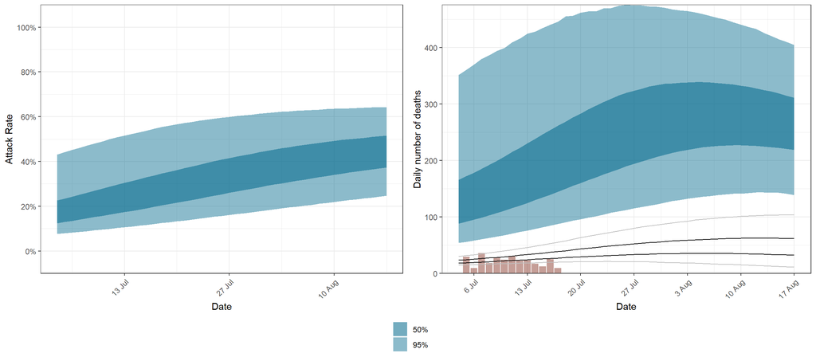

The attack rate and deaths over a longer period for both the constant mobility and increased mobility scenarios are plotted below:

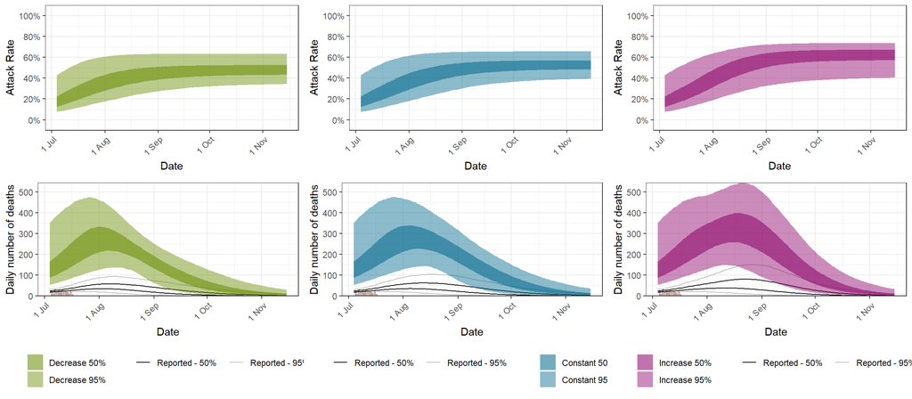